# Pokročilé metody text miningu

# Příprava dat

Podívejme se na recenze k filmům ze stránky IMDB (*Internet Movie Database*), které můžeme najít jako součást balíčku *textdata*. Začněme tedy načtením potřebných balíčků.

```r
library(tidytext)
library(textdata)
library(tidyverse)
library(tm)
library(koRpus)
library(koRpus.lang.en)
```

A stáhněme si potřebná data (stáhne se přes 300 MB dat) a podívejme se na prvních 10 záznamů.

```r
imdb <- dataset_imdb()

head(imdb, n=10)
```

| sentiment | text |
| --- | --- |
| neg | Story of a man who has unnatural feelings for a pig. Starts out with a opening scene that is a terrific example of absurd comedy. A formal orchestra audience is turned into an insane, violent mob by t… |
| neg | Airport '77 starts as a brand new luxury 747 plane is loaded up with valuable paintings & such belonging to rich businessman Philip Stevens (James Stewart) who is flying them & a bunch of VIP's to his… |
| neg | This film lacked something I couldn't put my finger on at first: charisma on the part of the leading actress. This inevitably translated to lack of chemistry when she shared the screen with her leadin… |
| neg | Sorry everyone,,, I know this is supposed to be an "art" film,, but wow, they should have handed out guns at the screening so people could blow their brains out and not watch. Although the scene desig… |
| neg | When I was little my parents took me along to the theater to see Interiors. It was one of many movies I watched with my parents, but this was the only one we walked out of. Since then I had never seen… |
| neg | "It appears that many critics find the idea of a Woody Allen drama unpalatable." And for good reason: they are unbearably wooden and pretentious imitations of Bergman. And let's not kid ourselves: cri… |
| neg | The second attempt by a New York intellectual in less than 10 years to make a "Swedish" film - the first being Susan Sontag's "Brother Carl" (which was made in Sweden, with Swedish actors, no less!) T… |
| neg | I don't know who to blame, the timid writers or the clueless director. It seemed to be one of those movies where so much was paid to the stars (Angie, Charlie, Denise, Rosanna and Jon) that there wasn… |
| neg | This film is mediocre at best. Angie Harmon is as funny as a bag of hammers. Her bitchy demeanor from "Law and Order" carries over in a failed attempt at comedy. Charlie Sheen is the only one to come … |
| neg | The film is bad. There is no other way to say it. The story is weak and outdated, especially for this country. I don't think most people know what a "walker" is or will really care. I felt as if I was… |

Data obsahují pouze dvě proměnné. První proměnná značí, jedná-li se o pozitivní nebo negativní recenzi a ve druhé proměnné je uložen samotný text recenze. Navíc přidáme identifikátor původní recenze.

```r
imdb <- imdb %>%
  mutate(id = row_number())
```

Celý dataset obsahuje celkem 25 tisíc recenzí. Pro každou recenzi máme k dispozici hodnocení, zda-li se jedná o pozitivní (7 a více hvězdiček) nebo negativní (4 a méně hvězdiček) recenzi. Navíc žádný film nemá v datasetu více jak 30 recenzí, protože různé recenze ke stejnému filmu mají tendence být silně korelovany.

Protože celý proces je celkově náročný na výpočetní výkon, použijeme jenom menší vzorek (10000 náhodně zvolených recenzí), abychom veškeré výpočty urychlili.

```r
# nastaveni generatoru nahodnych cisel
set.seed(42)

imdb_split <- sample(1:25000, 10000, replace=FALSE)

imdb <- imdb %>%
  inner_join(tibble(id = imdb_split), by="id")
```

Zkontrolujme, že máme zahrnuty pozitivní a negativní recenze v relativně stejném poměru.

```r
imdb %>%
  count(sentiment)
```

| sentiment | n |
| --- | --- |
| neg | 5061 |
| pos | 4939 |

A ještě si upravíme identifikátor, aby nabýval hodnot od 1 do 10000.

```r
imdb <- imdb %>%
  mutate(id = row_number())
```

Jako další krok provedeme tokenizaci a rovnou se podíváme, jaká nejčastější slova se v datech vyskytují.

```r
imdb_tidy <- imdb %>%
  unnest_tokens(word, text)

words <- imdb_tidy %>%
  count(word, sort=TRUE)

words
```

| word | n |
| --- | --- |
| the | 136045 |
| and | 66088 |
| a | 65754 |
| of | 58933 |
| to | 54732 |
| is | 43531 |
| br | 41176 |
| in | 37937 |
| it | 31814 |
| i | 30519 |

[output cut: 990 more lines]

Nelze si nevšimnout, že většina nejčastějších slov se řadí mezi tzv. stopwords, které za okamžik odstraníme. Nejprve však ještě provedeme lemmatizaci, abychom sjednotili stejná slova, která mají jiný tvar. Tato operace může trvat na velkém vzorku i několik minut.

```r
set.kRp.env(TT.cmd="manual", TT.options=list(path="C:\\TreeTagger", preset="en"), lang="en")

lemmatization <- treetag(words$word, treetagger="manual", format="obj",
                      TT.tknz=FALSE , lang="en",
                      TT.options=list(path="C:/treeTagger", preset="en"))

lemmatization@tokens
```

| doc_id | token | tag | lemma | lttr | wclass | desc | stop | stem | idx | sntc |
| --- | --- | --- | --- | --- | --- | --- | --- | --- | --- | --- |
| tempTextFromObject24b43e821c86.txt | the | AT0 | the | 3 | article | NA | NA | NA | 1 | 1 |
| tempTextFromObject24b43e821c86.txt | and | CJC | and | 3 | conjunction | NA | NA | NA | 2 | 1 |
| tempTextFromObject24b43e821c86.txt | a | AT0 | a | 1 | article | NA | NA | NA | 3 | 1 |
| tempTextFromObject24b43e821c86.txt | of | PRF | of | 2 | preposition | NA | NA | NA | 4 | 1 |
| tempTextFromObject24b43e821c86.txt | to | PRP | to | 2 | preposition | NA | NA | NA | 5 | 1 |
| tempTextFromObject24b43e821c86.txt | is | VBZ | be | 2 | verb | NA | NA | NA | 6 | 1 |
| tempTextFromObject24b43e821c86.txt | br | NN0 | br | 2 | noun | NA | NA | NA | 7 | 1 |
| tempTextFromObject24b43e821c86.txt | in | PRP | in | 2 | preposition | NA | NA | NA | 8 | 1 |
| tempTextFromObject24b43e821c86.txt | it | PNP | it | 2 | pronoun | NA | NA | NA | 9 | 1 |
| tempTextFromObject24b43e821c86.txt | i | ZZ0 | i | 1 | letter | NA | NA | NA | 10 | 1 |

[output cut: 990 more lines]

Lemmatizovaná slova najdeme ve sloupci *lemma*. Vytvořme nyní slovník *token* - *lemma*, který potom spojíme s původním datasetem. Musíme si dát však pozor na některé aspekty zvoleného algoritmu, které musíme zohlednit v našem slovníku.

Za prvé algoritmus k některým slovům nenašel jejich základní tvar. Ty poznáme podle hodnoty ve sloupci *lemma* a odstraníme je ze slovníku.

Za druhé máme k některým slovům na výběr více variant lemmatizovaných slov. Ty poznáme podle hodnoty *slovo1|slovo2|slovo3* ve sloupci *lemma* a v tomto případě vezmeme jenom první možnost.

A za třetí slovník obsahuje i různé netextové prvky (apostrofy, číslovky), které ze slovníku taktéž odstraníme.

```r
lemmatization_dict <- tibble(word=lemmatization@tokens$token, lemma=lemmatization@tokens$lemma) %>%
  filter(lemma != "<unknown>") %>%
  mutate(lemma = str_replace(lemma, "\\|.+", "")) %>%
  filter(str_detect(lemma, "[^a-z]", negate=TRUE)) %>%
  group_by(word) %>%
  slice(1)

lemmatization_dict
```

| word | lemma |
| --- | --- |
| a | a |
| aaa | aaa |
| aah | aah |
| aaker | aaker |
| aamir | aamir |
| aargh | aargh |
| ab | ab |
| aback | aback |
| abandon | abandon |
| abandoned | abandon |

[output cut: 990 more lines]

Když máme připravený slovník, tak ho spojíme s původním datasetem.

```r
imdb_final <- imdb_tidy %>%
  inner_join(lemmatization_dict, by="word")

imdb_final
```

| sentiment | id | word | lemma |
| --- | --- | --- | --- |
| neg | 1 | airport | airport |
| neg | 1 | starts | start |
| neg | 1 | as | as |
| neg | 1 | a | a |
| neg | 1 | brand | brand |
| neg | 1 | new | new |
| neg | 1 | luxury | luxury |
| neg | 1 | plane | plane |
| neg | 1 | is | be |
| neg | 1 | loaded | load |

[output cut: 990 more lines]

V dalším kroku odstraníme stopwords.

```r
imdb_final <- imdb_final %>%
  mutate(word = lemma) %>%
  select(sentiment, id, word) %>%
  anti_join(stop_words, by="word")

imdb_final %>%
  count(word, sort=TRUE)
```

| word | n |
| --- | --- |
| br | 41176 |
| movie | 20747 |
| film | 18857 |
| time | 6387 |
| watch | 5617 |
| character | 5513 |
| story | 5303 |
| bad | 4896 |
| scene | 4266 |
| people | 3706 |

[output cut: 990 more lines]

Po odstranění stopwords je nejčastějším slovem *br*. Jedná se však o html tag, který značí odřádkování a z další analýzy jej odstraníme.

```r
imdb_final <- imdb_final %>%
  filter(word != "br")

imdb_final %>%
  count(word, sort=TRUE)
```

| word | n |
| --- | --- |
| movie | 20747 |
| film | 18857 |
| time | 6387 |
| watch | 5617 |
| character | 5513 |
| story | 5303 |
| bad | 4896 |
| scene | 4266 |
| people | 3706 |
| play | 3430 |

[output cut: 990 more lines]

Jako poslední krok při přípravě dat přejmenujeme proměnnou *sentiment* na *rating*, která by se nám mohla plést se stejně pojmenovanou proměnnou v sentimentových slovnících.

```r
imdb_final <- imdb_final %>%
  rename(rating = sentiment)

imdb_final
```

| rating | id | word |
| --- | --- | --- |
| neg | 1 | airport |
| neg | 1 | start |
| neg | 1 | brand |
| neg | 1 | luxury |
| neg | 1 | plane |
| neg | 1 | load |
| neg | 1 | valuable |
| neg | 1 | painting |
| neg | 1 | belong |
| neg | 1 | rich |

[output cut: 990 more lines]

# Analýza sentimentu

Zkusme se rychle podívat na sentiment upraveného datasetu. Jako první si vykreslíme 10 nejčastějších slov v pozitivních a negativních recenzích.

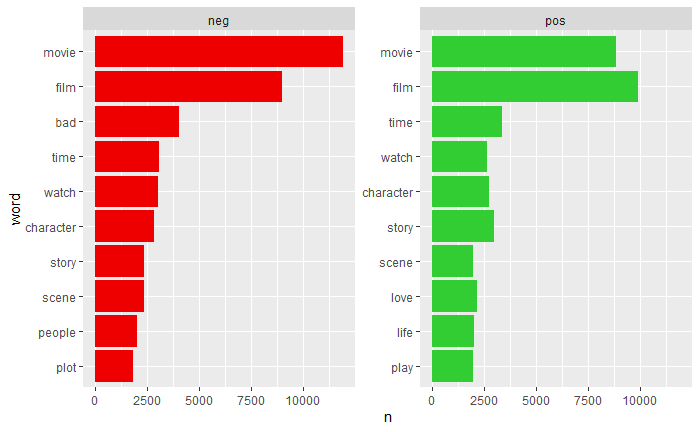

```r
imdb_final %>%
  count(rating, word, sort=TRUE) %>%
  group_by(rating) %>%
  top_n(10,n ) %>%
  ungroup() %>%
  mutate(word = reorder(word, n)) %>%
  ggplot(aes(x=word, y=n, fill=factor(rating))) +
  geom_col(show.legend = FALSE) +
  facet_wrap(~rating, scales = "free_y") +
  scale_fill_manual(
    values=c("red2", "limegreen")
    ) +
  coord_flip()
```

Oblíbený způsob vizualizace slov v rozdílných kategoriích je i tzv. *wordcloud*, který je dostupný ve stejnojmenném balíčku.

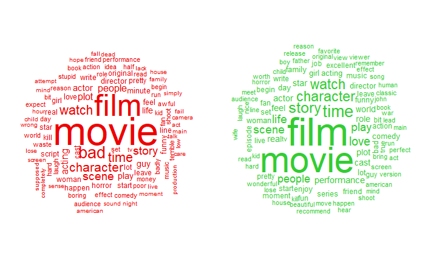

```r
# install.packages("wordcloud")
library(wordcloud)

par(mfrow=c(1,2), mar=c(0,0,0,0))

imdb_final %>%
  filter(rating == "neg") %>%
  count(word) %>%
  with(wordcloud(word, n, max.words = 100, random.order=FALSE, color="red2"))

imdb_final %>%
  filter(rating == "pos") %>%
  count(word) %>%
  with(wordcloud(word, n, max.words = 100, random.order=FALSE, color="limegreen"))
```

Nejprve se podívejme na slovník *AFINN*, který má pro každý záznam ve slovníku přiřazené číslo od -5 do 5 podle toho, jak moc je dané slovo negativní nebo pozitivní.

Pro každou recenzi si vypočítáme celkové skóre jako součet sentimentů pro všechny slova vážené četností. Toto celkové skóre můžeme zobrazit v boxplotu a porovnat hodnoty pro pozitivní a negativní recenze.

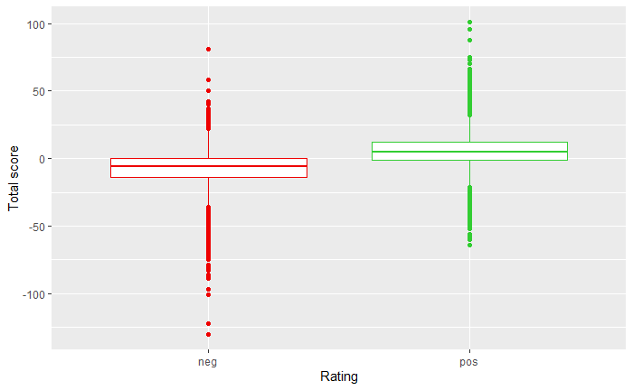

```r
imdb_final %>%
  count(rating, id, word) %>%
  inner_join(get_sentiments("afinn"), by="word") %>%
  mutate(score = n*value) %>%
  group_by(rating, id) %>%
  summarise(total_score = sum(score)) %>%
  ggplot(aes(x=factor(rating), y=total_score, color=factor(rating))) +
  geom_boxplot(show.legend=FALSE) +
  scale_color_manual(
    values=c("red2", "limegreen")) +
  labs(
    x="Rating",
    y="Total score"  )
```

Zkusme se ještě podívat blíže, jak odpovídá hodnota ze slovníku *AFINN* tomu, co pozorujeme v datech. Pro každý výskyt daného slova v pozitivní recenzi přičteme ke skóre daného slova +1 a naopak za výskyt v negativním slově odečteme -1. Takto získané skóre si porovnáme s hodnotami z *AFINN* slovníku.

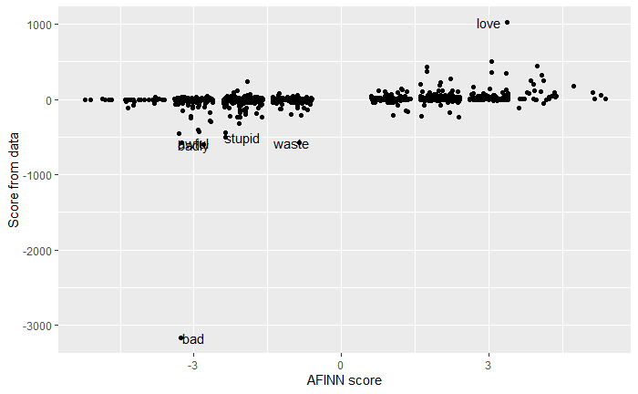

```r
score_comparison <- imdb_final %>%
  group_by(rating, word) %>%
  summarise(n = sum(n())) %>%
  mutate(n = if_else(rating == "neg", -n, n)) %>%
  group_by(word) %>%
  summarise(n = sum(n)) %>%
  inner_join(get_sentiments("afinn"), by="word")

ggplot(data=score_comparison, aes(x=value, y=n)) +
  geom_jitter() +
  geom_text(
    data = score_comparison %>%
      filter(!between(n, -500, 500)),
    aes(x=value, y=n, label=word)) +
  labs(
    x="AFINN score",
    y="Score from data")
```

Jako druhý v pořadí jsme si minule představili slovník *bing*, který slovo rozděluje na pozitivní a negativní. Podívejme se, jak dobře tento slovník umí odhadnout, jestli je daná recenze pozitivní nebo negativní. Vypočítáme si kumulativní skóre tak, že každé pozitivní slovo nám zvýší skóre o 1 a naopak negativní slovo sníží skóre o 1. Toto kumulativní skóre si vykreslíme a podíváme se, jestli se pozitivní recenze s přibývajícími slovy stává ještě pozitivnější a nebo naopak.

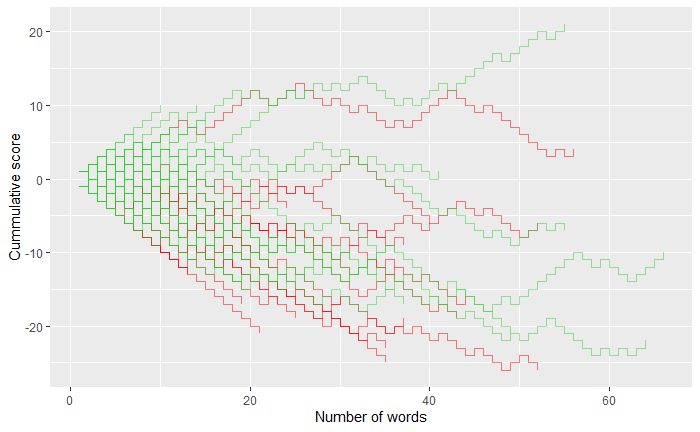

```r
set.seed(42)

imdb_final %>%
  filter(id %in% sample(1:10000, 100)) %>%
  inner_join(get_sentiments("bing"), by="word") %>%
  group_by(rating, id) %>%
  mutate(
    score = if_else(sentiment == "positive", 1, -1),
    rank = row_number(),
    cum_score = cumsum(score)) %>%
  ggplot(aes(x=rank, y=cum_score, group=id, col=rating)) +
  geom_step(alpha=0.5, show.legend=FALSE) +
    scale_color_manual(
    values=c("red2", "limegreen")) +
  labs(
    x="Number of words",
    y="Cummulative score")
```

# Klasifikace

Podívejme se na klasifikační úlohu, kdy se budeme snažit natrénovat rozhodovací strom, který na základě obsahu (slov) dané recenze rozhodne, jestli se jedná o pozitivní nebo negativní recenzi.

Začneme s tím, že si převedeme text do vhodné podoby, která může sloužit jako vstup do našeho modelu, takže vytvoříme *document-term matici*.

```r
imdb_dtm <- imdb_final %>%
  group_by(id) %>%
  count(word) %>%
  cast_dtm(id, word, n)

inspect(imdb_dtm)
```

```
<<DocumentTermMatrix (documents: 10000, terms: 26375)>>
Non-/sparse entries: 653305/263096695
Sparsity           : 100%
Maximal term length: 20
Weighting          : term frequency (tf)
Sample             :
      Terms
Docs   bad film character movie people play scene story time watch
  1397   3    2        10     6      1    1     1     3    0     0
  210    1   13         7     8      0    3     6     4    1     1
  2221   1    3         2     3      0    2     1     0    1     1
  3976   1    3         0     0      1    0     0     2    2     0
  4056  15    0         2    26      1    2     5     1    1     0
  5083   0   10         6    12      6    1     6     6   13     0
  6744   0    1         1    16      0    2    10     3    4     1
  7388   3   17         5     0      3    0     1     1    2     0
  7519   1   24         9     0     12    1     9     0    5     1
  8904   0    8         1     1      0    0     4     2    0     1
```

Vytvořená document-term matice má přes 26 tisíc sloupců. My bychom chtěli ale tento počet snížit, abychom urychlili odhadt modelu a odstraníme tedy slova, která chybí ve více jak 95 % dokumentů (recenzí). Tímto se nám počet sloupců sníží na 198.

```r
imdb_dtm <- removeSparseTerms(imdb_dtm, sparse = .95)

inspect(imdb_dtm)
```

```
<<DocumentTermMatrix (documents: 10000, terms: 198)>>
Non-/sparse entries: 186619/1793381
Sparsity           : 91%
Maximal term length: 12
Weighting          : term frequency (tf)
Sample             :
      Terms
Docs   bad film character movie people play scene story time watch
  1397   3    2        10     6      1    1     1     3    0     0
  210    1   13         7     8      0    3     6     4    1     1
  3262   6   10         0     0      1    0     2     3    1     2
  3978   3   11         5     6      4    0     4     1    1     0
  4056  15    0         2    26      1    2     5     1    1     0
  4962   2   15         3     2      0    0     2     4    0     4
  5083   0   10         6    12      6    1     6     6   13     0
  6744   0    1         1    16      0    2    10     3    4     1
  7519   1   24         9     0     12    1     9     0    5     1
  9588   1    5         2    23      5    1     2     3    5     7
```

```r
set.seed(42)

split <- sort(sample(1:10000, 6000, replace=FALSE))

imdb_train <- as.matrix(imdb_dtm)[split,]
imdb_test <- as.matrix(imdb_dtm)[-split,]

rating_train <- imdb_final %>%
  select(rating, id) %>%
  unique() %>%
  filter(id %in% split)

rating_test <- imdb_final %>%
  select(rating, id) %>%
  unique() %>%
  filter(!id %in% split)
```

Máme všechno připravené a nyní si odhadneme rozhodovací strom. Budeme používat funkci *train* z balíčku *caret*.

```r
# install.packages("caret")
library(caret)

classifier_tree <- train(x=imdb_train,
                    y=as.factor(rating_train$rating),
                    method="rpart",
                    cp=0.002,
                    maxdepth=20)
```

V dalším kroku si můžeme prohlédnout detaily odhadnutého modelu.

```r
classifier_tree$finalModel
```

```
n= 6000

node), split, n, loss, yval, (yprob)
      * denotes terminal node

1) root 6000 2964 neg (0.50600000 0.49400000)
  2) bad>=0.5 1695  392 neg (0.76873156 0.23126844) *
  3) bad< 0.5 4305 1733 pos (0.40255517 0.59744483)
    6) waste>=0.5 191   17 neg (0.91099476 0.08900524) *
    7) waste< 0.5 4114 1559 pos (0.37894993 0.62105007) *
```

A vykreslit ho.

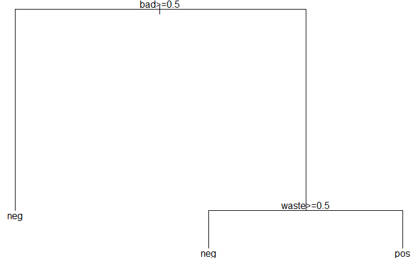

```r
par(mar=c(0,0,0,0))

plot(classifier_tree$finalModel)
text(classifier_tree$finalModel)
```

Podívejme se i na rozhodovací les, který bude tvořit 10 rozhodovacích stromů.

```r
classifier_forest <- train(x=imdb_train,
                    y=as.factor(rating_train$rating),
                    method="ranger",
                    num.trees=10,
                    importance="impurity")
```

Prohlédněme si detaily odhadnutého modelu.

```r
classifier_forest$finalModel
```

```
Ranger result

Call:
 ranger::ranger(dependent.variable.name = ".outcome", data = x,      mtry = min(param$mtry, ncol(x)), min.node.size = param$min.node.size,      splitrule = as.character(param$splitrule), write.forest = TRUE,      probability = classProbs, ...)

Type:                             Classification
Number of trees:                  10
Sample size:                      6000
Number of independent variables:  198
Mtry:                             100
Target node size:                 1
Variable importance mode:         impurity
Splitrule:                        extratrees
Number of random splits:          1
OOB prediction error:             31.48 %
```

Můžeme se podívat na slova (proměnné), které jsou dle rozhodovacího lesu nejdůležitější.

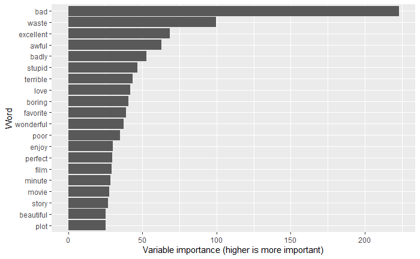

```r
classifier_forest$finalModel %>%
  ranger::importance() %>%
  enframe(name="variable", value="varimp") %>%
  top_n(n=20, wt=varimp) %>%
  ggplot(aes(x=fct_reorder(variable, varimp), y=varimp)) +
  geom_col() +
  coord_flip() +
  labs(x="Word",
       y="Variable importance (higher is more important)")
```

Nyní pomocí se podívejme, jak by odhadnuté modely klasifikují testovací data.

```r
predictions_tree <- predict(classifier_tree, newdata=imdb_test)
predictions_forest <- predict(classifier_forest, newdata=imdb_test)
```

Vektor *predictions* obsahuje predikce, takže ke každému záznamu dostaneme buď *pos* pro predikci pozitivní recenze, nebo *neg* pro predikci negativní recenze. Můžeme se podívat, jak velká část recenzí byla správně predikována.

Pro rozhodovací strom:

```r
# install.packages("yardstick")
library(yardstick)

rating_test %>%
  mutate(prediction = as.factor(predictions_tree),
         rating = as.factor(rating)) %>%
  conf_mat(rating, prediction)
```

```
          Truth
Prediction  neg  pos
       neg  995  288
       pos 1030 1687
```

Pro rozhodovací les:

```r
rating_test %>%
  mutate(prediction = as.factor(predictions_forest),
         rating = as.factor(rating)) %>%
  conf_mat(rating, prediction)
```

```
          Truth
Prediction  neg  pos
       neg 1478  501
       pos  547 1474
```